# Ontario Gateway

Team7: Shihan Wang, Zhengyu Jiang, Karina Mark, Yamini Nekkanti

11/10/2019

# *Ontario Gateway*

## Memo

Dear Mary Litton,

We have taken into account the risks, profits from rebates, and losses to conclude the best insurance policy to protect us from unanticipated losses of aircraft and existing debt obligations. We understood bankruptcy and unanticipated negative cash flow aren’t an option as the company is trying to expand operations under a highly leveraged capital structure. With the company’s margin of safety of $37M per year ($185M over five years), we provided three optimal insurance policies depending on the situation threshold:

If Ontario Gateway prefers to make sure that it will not go bankrupt in one year, we recommend HIC insurance policy. If Ontario Gateway prefers to minimize the expected net losses of the long term, we recommend the RCNC2 insurance policy. If Ontario Gateway prefers to emphasize both the 1-year bankruptcy risk and long-term net loss, we recommend HIC insurance policy.

We didn’t provide an option to withdraw from insurance because the bankruptcy risk is significantly high for year one. Although bankruptcy risk is lower over 5 years, we can’t rely on that the risk actually decreased. Therefore, we used the year one bankruptcy as the main metric of risk. Based on the one-year metric, we concluded the company needs to buy insurance.

Based on the insurance plans and the company’s financials provided, HIC insurance policy protects the company’s risk and satisfies the margin of safety. We believe there are sufficient facts provided to analyze and conclude our recommendations. Our analysis steps are provided in the Appendix. If you need to discuss any further, we would love to set up a meeting with you later this week.

Sincerely, Team 7 (Shihan Wang, Zhengyu Jiang, Karina Mark, Yamini Nekkanti)

## Appendix

Please refer to the RMD file, Ontario_GateWay, for further coding details.

#### Steps to Achieve Our Recommendations

First, we separately simulated 1-year and 5-year losses for Ontario Gateway by simulating the possibility of crashing for 4 plane models and the cost of incidental damages. We compared 1-year and 5-year losses with the firm’s margin of safety of $37M per year ($185M over five years) and obtained that the 1-year bankruptcy rate is 2.46% while the 5-year bankruptcy rate is 0.04%.

Second, we calculated the insurance cost in year 1 and compared it with the margin of safety($37M). Based on the results of the simulation, we found under HIC policy it is impossible for the company to go bankrupt. In other words, the HIC policy is associated with the lowest probability of going bankrupt among four policies in the first year.

Third, we determined the cumulative insurance cost over a period of 5 years. Compared to the previous situation, we need to consider the rebates from RCNC1 and HIC policy as well. After taking the rebates into account, we discovered that the RCNC2 policy is associated with the lowest average loss($32.68M) among four policies.

We concluded our summarized findings and simulation results in the following table:

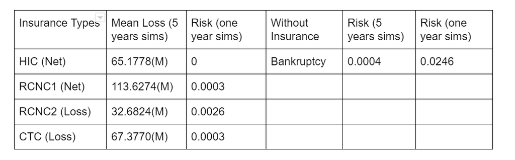

#### 1M Simulations for 1-Year Bankruptcy Risk

```r
simdat <- simulater(
  unif = "Cost 1 5",
  binom = c(
    "B7572 96444 0.0000002",
    "A3402 11542.5 0.0000002",
    "A3403 16416 0.0000002"
  ),
  form = c(
    "total = Cost + B7572*56.4 + A3402*78.9 + A3403*88.5",
    "bankrupt = total > 37"
  ),
  seed = 1234,
  nr = 1000000
)
summary(simdat, dec = 4)
```

```
Simulation
Simulations: 1,000,000
Random seed: 1234
Sim data   : simdat
Binomial   : B7572 96444 0.0000002; A3402 11542.5 0.0000002; A3403 16416 0.0000002
Uniform    : Cost 1 5
Formulas   :
    total = Cost + B7572*56.4 + A3402*78.9 + A3403*88.5
    bankrupt = total > 37

Variables:
 variable     n_obs   mean      sd    min    p25 median    p75      max
    A3402 1,000,000 0.0022  0.0473 0.0000 0.0000 0.0000 0.0000   2.0000
    A3403 1,000,000 0.0033  0.0575 0.0000 0.0000 0.0000 0.0000   2.0000
    B7572 1,000,000 0.0194  0.1392 0.0000 0.0000 0.0000 0.0000   3.0000
    Cost  1,000,000 2.9992  1.1553 1.0000 1.9974 2.9988 4.0008   5.0000
    total 1,000,000 4.5603 10.1379 1.0000 2.0221 3.0486 4.0756 206.0164

Logicals:
         TRUE (nr)   TRUE (prop)
bankrupt      24,597      0.0246
```

```r
register("simdat")
```

#### 1M Simulations for 5-Years Bankruptcy Risk

```r
repdat <- repeater(
  simdat,
  nr = 5,
  vars = c("A3403", "A3402", "B7572", "Cost"),
  sum_vars = "total",
  form = "bankrupt5 = total > 185",
  seed = 1234
)
summary(repdat, dec = 4)
```

```
Repeated simulation
Simulations   : 1,000,000
Repetitions   : 5
Re-simulated  : A3403, A3402, B7572, Cost
Group by      : Simulation
Function      : sum
Random  seed  : 1234
Simulated data: simdat
Repeat  data  : repdat
Formulas      :
    bankrupt5 = total > 185

Variables:
     variable     n_obs    mean      sd    min     p25  median     p75      max
 sum of total 1,000,000 22.8078 22.6834 5.8458 13.4771 15.4448 17.7255 324.1123

Logicals:
          TRUE (nr)   TRUE (prop)
bankrupt5         351      0.0004
```

```r
register("repdat")
```

#### 1M Simulations for 1-Year Cost for 4 Insurance Policies

```r
simdat2 <- simulater(
  unif = "Cost 1 5",
  binom = c(
    "B7572 96444 0.0000002",
    "A3402 11542.5 0.0000002",
    "A3403 16416 0.0000002"
  ),
  form = c(
    "total = Cost + B7572*56.4 + A3402*78.9 + A3403*88.5",
    "bankrupt = total > 37",
    "RCNC1_prof = 0.0045 * 5958.3 - 0.9 * total",
    "HIC_prof = 0.00165 * 5958.3 - pmax(total - 24, 0)",
    "RCNC1_loss = 0.0045 * 5958.3 + 0.1 * total",
    "RCNC2_loss = 0.001 * 5958.3 + total - pmin(0.9*total, 0.01*5958.3)",
    "CTC_loss = 13 + total - pmin(0.9*total, 80)",
    "HIC_loss = 0.00165 * 5958.3 + total - pmax(total - 24, 0)",
    "RCNC1_bankrupt = RCNC1_loss > 37",
    "RCNC2_bankrupt = RCNC2_loss > 37",
    "CTC_bankrupt = CTC_loss > 37",
    "HIC_bankrupt = HIC_loss > 37"
  ),
  seed = 1234,
  nr = 1000000
)
summary(simdat2, dec = 4)
```

```
Simulation
Simulations: 1,000,000
Random seed: 1234
Sim data   : simdat2
Binomial   : B7572 96444 0.0000002; A3402 11542.5 0.0000002; A3403 16416 0.0000002
Uniform    : Cost 1 5
Formulas   :
    total = Cost + B7572*56.4 + A3402*78.9 + A3403*88.5
    bankrupt = total > 37
    RCNC1_prof = 0.0045 * 5958.3 - 0.9 * total
    HIC_prof = 0.00165 * 5958.3 - pmax(total - 24, 0)
    RCNC1_loss = 0.0045 * 5958.3 + 0.1 * total
    RCNC2_loss = 0.001 * 5958.3 + total - pmin(0.9*total, 0.01*5958.3)
    CTC_loss = 13 + total - pmin(0.9*total, 80)
    HIC_loss = 0.00165 * 5958.3 + total - pmax(total - 24, 0)
    RCNC1_bankrupt = RCNC1_loss > 37
    RCNC2_bankrupt = RCNC2_loss > 37
    CTC_bankrupt = CTC_loss > 37
    HIC_bankrupt = HIC_loss > 37

Variables:
   variable     n_obs    mean      sd       min     p25  median     p75      max
 A3402      1,000,000  0.0022  0.0473    0.0000  0.0000  0.0000  0.0000   2.0000
 A3403      1,000,000  0.0033  0.0575    0.0000  0.0000  0.0000  0.0000   2.0000
 B7572      1,000,000  0.0194  0.1392    0.0000  0.0000  0.0000  0.0000   3.0000
 Cost       1,000,000  2.9992  1.1553    1.0000  1.9974  2.9988  4.0008   5.0000
 CTC_loss   1,000,000 13.4746  1.3995   13.1000 13.2022 13.3049 13.4076 139.0164
 HIC_loss   1,000,000 13.3468  3.4472   10.8312 11.8533 12.8798 13.9068  33.8312
 HIC_prof   1,000,000  8.7865  6.9350 -172.1852  9.8312  9.8312  9.8312   9.8312
 RCNC1_loss 1,000,000 27.2684  1.0138   26.9124 27.0146 27.1172 27.2199  47.4140
 RCNC1_prof 1,000,000 22.7081  9.1241 -158.6024 23.1443 24.0686 24.9924  25.9123
 RCNC2_loss 1,000,000  6.5358  2.5282    6.0583  6.1605  6.2632  6.3659 152.3917
 total      1,000,000  4.5603 10.1379    1.0000  2.0221  3.0486  4.0756 206.0164

Logicals:
               TRUE (nr)   TRUE (prop)
bankrupt            24,597      0.0246
RCNC1_bankrupt         303      0.0003
RCNC2_bankrupt       2,626      0.0026
CTC_bankrupt           303      0.0003
HIC_bankrupt             0           0
```

```r
register("simdat2")
```

#### 1M Simulations for 5-Years Cost for 4 Insurance Policies

```r
repdat2 <- repeater(
  simdat2,
  nr = 5,
  vars = c("Cost", "B7572", "A3402", "A3403"),
  sum_vars = c(
    "RCNC1_prof", "HIC_prof", "RCNC1_loss", "RCNC2_loss",
    "CTC_loss", "HIC_loss", "total"
  ),
  form = c(
    "RCNC1_net = RCNC1_loss - 0.2 * pmax(RCNC1_prof, 0)",
    "HIC_net = HIC_loss - 0.035 * pmax(HIC_prof, 0)"
  ),
  seed = 1234
)
summary(repdat2, dec = 4)
```

```
Repeated simulation
Simulations   : 1,000,000
Repetitions   : 5
Re-simulated  : Cost, B7572, A3402, A3403
Group by      : Simulation
Function      : sum
Random  seed  : 1234
Simulated data: simdat2
Repeat  data  : repdat2
Formulas      :
    RCNC1_net = RCNC1_loss - 0.2 * pmax(RCNC1_prof, 0)
    HIC_net = HIC_loss - 0.035 * pmax(HIC_prof, 0)

Variables:
          variable     n_obs     mean      sd       min      p25   median      p75      max
 sum of CTC_loss   1,000,000  67.3770  3.1687   65.5846  66.3477  66.5445  66.7726 204.6668
 sum of HIC_loss   1,000,000  66.7380  7.7071   55.0018  62.6331  64.6007  66.8815 149.1112
 sum of HIC_net    1,000,000  65.1778  8.1198   53.2814  60.9126  62.8803  65.1610 149.1112
 sum of HIC_prof   1,000,000  43.9302 15.5253 -196.6040  49.1560  49.1560  49.1560  49.1560
 sum of RCNC1_loss 1,000,000 136.3425  2.2683  134.6463 135.4095 135.6062 135.8343 166.4730
 sum of RCNC1_net  1,000,000 113.6274  6.2964  108.8862 111.0230 111.5739 112.2125 166.4730
 sum of RCNC1_prof 1,000,000 113.5348 20.4150 -157.6393 118.1088 120.1615 121.9324 128.8005
 sum of RCNC2_loss 1,000,000  32.6824  5.6821   30.3761  31.1392  31.3360  31.5641 189.8753
 sum of total      1,000,000  22.8078 22.6834    5.8458  13.4771  15.4448  17.7255 324.1123
```

```r
register("repdat2")
```